# DATA 624 - Project 2

Peter Phung, Krutika Patel, Alec McCabe, Anjal

2023-05-10

# Problem Statement

This is role playing. I am your new boss. I am in charge of production at ABC Beverage and you are a team of data scientists reporting to me. My leadership has told me that new regulations are requiring us to understand our manufacturing process, the predictive factors and be able to report to them our predictive model of PH.

Please use the historical data set I am providing. Build and report the factors in BOTH a technical and non-technical report. I like to use Word and Excel. Please provide your non-technical report in a business friendly readable document and your predictions in an Excel readable format. The technical report should show clearly the models you tested and how you selected your final approach.

Please submit both Rpubs links and .rmd files or other readable formats for technical and non-technical reports. Also submit the excel file showing the prediction of your models for pH.

# Problem Statement and Goals

In this report, we generate a machine learning model that is able to predict the PH level of a drink based on many predictors. The independent and dependent variables that are used in order to generate this model use data collected from 2,571 different drink samples. The analysis detailed in this report shows the testing of several models. There were 3 different model categories, and from each different category, several different models that were tested out:

- Linear Regression (Chapter 6 of Applied Predictive Modeling from Kuhn and Johnson)
  - Ordinary Linear Regression
  - Partial Least Squares
  - Penalized Regression
- Nonlinear Regression (Chapter 7 of Applied Predictive Modeling from Kuhn and Johnson)
  - Neural Networks
  - Multivariate Adaptive Regression Splines
  - Support Vector Machines
  - K-Nearest Neighbors
- Regression Trees and Rule-Based Models (Chapter 8 of Applied Predictive Modeling from Kuhn and Johnson)
  - Single Trees
  - Model Trees
  - Bagged Trees
  - Random Forest
  - Boosted Trees
  - Cubist

## Data Exploration

```r
beverage_train <- readxl::read_excel(
  "StudentData.xlsx"
  )
beverage_test <- readxl::read_excel(
  "StudentEvaluation.xlsx"
  )
```

```r
summary(beverage_train)
```

```
##   Brand Code         Carb Volume     Fill Ounces      PC Volume
##  Length:2571        Min.   :5.040   Min.   :23.63   Min.   :0.07933
##  Class :character   1st Qu.:5.293   1st Qu.:23.92   1st Qu.:0.23917
##  Mode  :character   Median :5.347   Median :23.97   Median :0.27133
##                     Mean   :5.370   Mean   :23.97   Mean   :0.27712
##                     3rd Qu.:5.453   3rd Qu.:24.03   3rd Qu.:0.31200
##                     Max.   :5.700   Max.   :24.32   Max.   :0.47800
##                     NA's   :10      NA's   :38      NA's   :39
##  Carb Pressure     Carb Temp          PSC             PSC Fill
##  Min.   :57.00   Min.   :128.6   Min.   :0.00200   Min.   :0.0000
##  1st Qu.:65.60   1st Qu.:138.4   1st Qu.:0.04800   1st Qu.:0.1000
##  Median :68.20   Median :140.8   Median :0.07600   Median :0.1800
##  Mean   :68.19   Mean   :141.1   Mean   :0.08457   Mean   :0.1954
##  3rd Qu.:70.60   3rd Qu.:143.8   3rd Qu.:0.11200   3rd Qu.:0.2600
##  Max.   :79.40   Max.   :154.0   Max.   :0.27000   Max.   :0.6200
##  NA's   :27      NA's   :26      NA's   :33        NA's   :23
##     PSC CO2           Mnf Flow       Carb Pressure1  Fill Pressure
##  Min.   :0.00000   Min.   :-100.20   Min.   :105.6   Min.   :34.60
##  1st Qu.:0.02000   1st Qu.:-100.00   1st Qu.:119.0   1st Qu.:46.00
##  Median :0.04000   Median :  65.20   Median :123.2   Median :46.40
##  Mean   :0.05641   Mean   :  24.57   Mean   :122.6   Mean   :47.92
##  3rd Qu.:0.08000   3rd Qu.: 140.80   3rd Qu.:125.4   3rd Qu.:50.00
##  Max.   :0.24000   Max.   : 229.40   Max.   :140.2   Max.   :60.40
##  NA's   :39        NA's   :2         NA's   :32      NA's   :22
##  Hyd Pressure1   Hyd Pressure2   Hyd Pressure3   Hyd Pressure4
##  Min.   :-0.80   Min.   : 0.00   Min.   :-1.20   Min.   : 52.00
##  1st Qu.: 0.00   1st Qu.: 0.00   1st Qu.: 0.00   1st Qu.: 86.00
##  Median :11.40   Median :28.60   Median :27.60   Median : 96.00
##  Mean   :12.44   Mean   :20.96   Mean   :20.46   Mean   : 96.29
##  3rd Qu.:20.20   3rd Qu.:34.60   3rd Qu.:33.40   3rd Qu.:102.00
##  Max.   :58.00   Max.   :59.40   Max.   :50.00   Max.   :142.00
##  NA's   :11      NA's   :15      NA's   :15      NA's   :30
##   Filler Level    Filler Speed   Temperature      Usage cont      Carb Flow
##  Min.   : 55.8   Min.   : 998   Min.   :63.60   Min.   :12.08   Min.   :  26
##  1st Qu.: 98.3   1st Qu.:3888   1st Qu.:65.20   1st Qu.:18.36   1st Qu.:1144
##  Median :118.4   Median :3982   Median :65.60   Median :21.79   Median :3028
##  Mean   :109.3   Mean   :3687   Mean   :65.97   Mean   :20.99   Mean   :2468
##  3rd Qu.:120.0   3rd Qu.:3998   3rd Qu.:66.40   3rd Qu.:23.75   3rd Qu.:3186
##  Max.   :161.2   Max.   :4030   Max.   :76.20   Max.   :25.90   Max.   :5104
##  NA's   :20      NA's   :57     NA's   :14      NA's   :5       NA's   :2
```

[output cut: 9 more lines]

```
##  Min.   :7.880   Min.   :0.00240   Min.   : 70.0   Min.   :44.00
##  1st Qu.:8.440   1st Qu.:0.02200   1st Qu.:100.0   1st Qu.:46.00
##  Median :8.540   Median :0.03340   Median :120.0   Median :46.00
##  Mean   :8.546   Mean   :0.04684   Mean   :109.3   Mean   :47.62
##  3rd Qu.:8.680   3rd Qu.:0.06000   3rd Qu.:120.0   3rd Qu.:50.00
##  Max.   :9.360   Max.   :0.40000   Max.   :140.0   Max.   :52.00
##  NA's   :4       NA's   :12        NA's   :2       NA's   :12
##  Air Pressurer      Alch Rel        Carb Rel      Balling Lvl
##  Min.   :140.8   Min.   :5.280   Min.   :4.960   Min.   :0.00
##  1st Qu.:142.2   1st Qu.:6.540   1st Qu.:5.340   1st Qu.:1.38
##  Median :142.6   Median :6.560   Median :5.400   Median :1.48
##  Mean   :142.8   Mean   :6.897   Mean   :5.437   Mean   :2.05
##  3rd Qu.:143.0   3rd Qu.:7.240   3rd Qu.:5.540   3rd Qu.:3.14
##  Max.   :148.2   Max.   :8.620   Max.   :6.060   Max.   :3.66
##                  NA's   :9       NA's   :10      NA's   :1
```

The summary above shows us that the `Brand Code` is a categorical variable. Therefore, we converted it into a factor so then R recognizes it as a categorical variable.

```r
beverage_train <- beverage_train %>%
  mutate(`Brand Code` = as.factor(`Brand Code`))

beverage_test <- beverage_test %>%
  mutate(`Brand Code` = as.factor(`Brand Code`))
```

The following code chunk produces a histogram for all of the continuous variables in the `beverage_train` data frame.

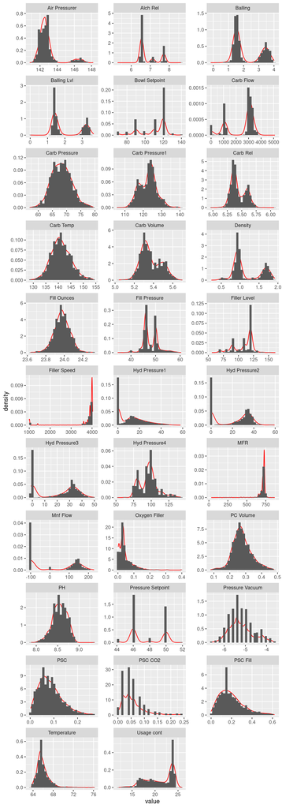

The histograms above reveal that the following variables have a normal/skewed distribution. Some of these variables that are listed below display skewness but that can be easily corrected with a transformation:

- `Carb Pressure`
- `Carb Temp`
- `Fill Ounces`
- `PC Volume`
- `Pressure Vacuum`
- `PH`
- `PSC`
- `PSC CO2`
- `PSC Fill`
- `Temperature`
- `MFR`
- `Oxygen Filler`

The other variables that are not listed above have a bimodal or greater than bimodal distribution:

- `Balling`
- `Balling Lvl`
- `Carb Flow`
- `Carb Pressure1`
- `Carb Rel`
- `Carb Volume`
- `Density`
- `Fill Pressure`
- `Hyd Pressure4`
- `Usage cont`
- `Pressure Setpoint`

Some of the predictors in particular have many observations that take on just one value. For example, for `Mnf Flow`, many of the observations take on a value of -100. Such variables include:

- `Filler Speed`
- `Hyd Pressure1`
- `Hyd Pressure2`
- `Hyd Pressure 3`
- `Mnf Flow`
- `Pressure Setpoint`

Boxplots for each of the continuous variables are shown below.

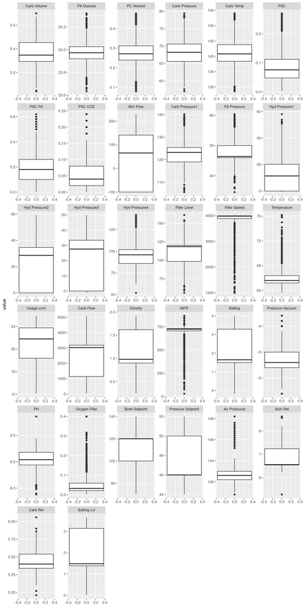

The output above shows us that the following variables have a significant number of outliers:

- `Filler Speed`
- `Temperature`
- `MFR`
- `Oxygen Filler`
- `Air Pressurer`

The correlation plot for the continuous variables is shown below.

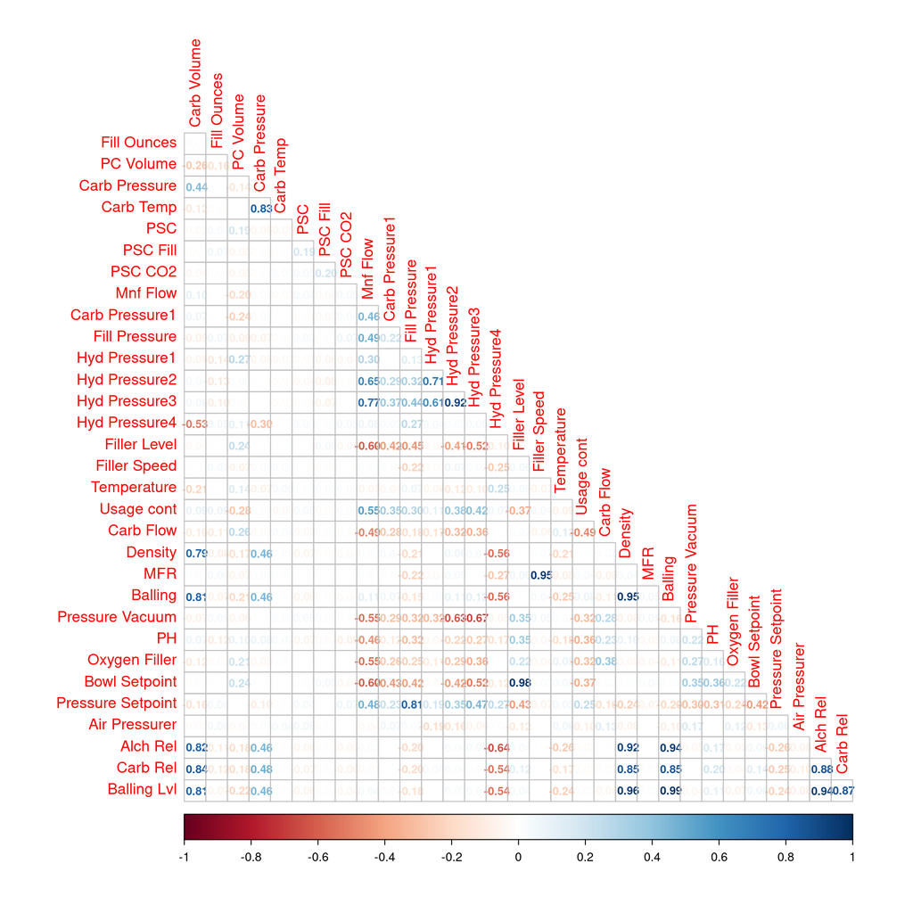

```r
corrplot::corrplot(cor(dplyr::select_if(beverage_train, is.numeric), use = "na.or.complete"),
         method = 'number',
         type = 'lower',
         diag = FALSE,
         number.cex = 0.75)
```

The correlation plot above reveals that some of the predictors have a very high correlation. On page 163 of the Applied Predictive Modeling textbook, it is recommended that the maximum absolute pairwise correlation between the predictors be less than 0.75. Therefore, the following predictor pairs have a correlation that is greater than 0.75:

- `Carb Pressure` and `Carb Temp`
- `Mnf Flow` and `Hyd Pressure3`
- `Hyd Pressure2` and `Hyd Pressure3`
- `Density` and `Carb Volume`
- `MFR` and `Filler Speed`
- `Balling` and `Carb Volume`
- `Density` and `Balling`
- `Filler Level` and `Bowl Setpoint`
- `Pressure Setpoint` and `Fill Pressure`
- `Alch Rel` and `Carb Volume`
- `Density` and `Alch Rel`
- `Balling` and `Alch Rel`
- `Carb Volume` and `Carb Rel`
- `Density` and `Carb Rel`
- `Balling` and `Carb Rel`
- `Alch Rel` and `Carb Rel`
- `Carb Volume` and `Balling Lvl`
- `Density` and `Balling Lvl`
- `Balling` and `Balling Lvl`
- `Alch Rel` and `Balling Lvl`
- `Carb Rel` and `Balling Lvl`

### NA exploration

As can be seen in the figure below, some of the columns have missing values. These missing values were imputed using the MICE algorithm. The methodology that was used is explained in the “Dealing with Missing Values” section.

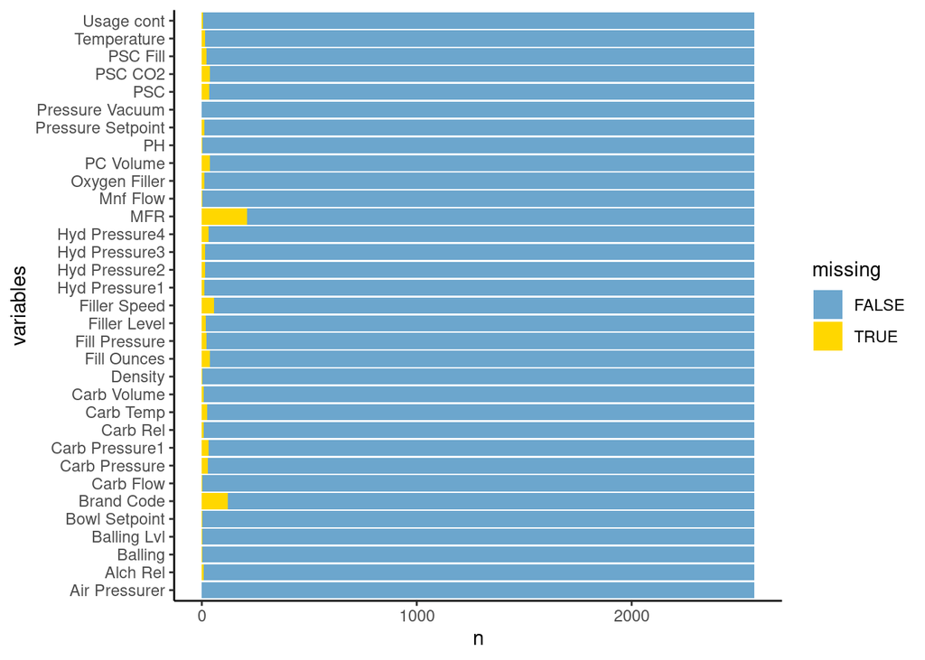

*Figure 5: Barplot of number of missing values for each predictor.*

# Data Preparation

### Dealing with Missing Values

In general, imputations by the means/medians is acceptable if the missing values only account for 5% of the sample. Peng et al.(2006) However, should the degree of missing values exceed 20% then using these simple imputation approaches will result in an artificial reduction in variability due to the fact that values are being imputed at the center of the variable’s distribution.

Our team decided to employ another technique to handle the missing values: Multiple Regression Imputation using the MICE package.

The MICE package in R implements a methodology where each incomplete variable is imputed by a separate model. [Alice](https://datascienceplus.com/imputing-missing-data-with-r-mice-package/) points out that plausible values are drawn from a distribution specifically designed for each missing datapoint. Many imputation methods can be used within the package. The one that was selected for the data being analyzed in this report is PMM (Predictive Mean Matching), which is used for quantitative data.

[Van Buuren](https://stefvanbuuren.name/fimd/sec-pmm.html) explains that PMM works by selecting values from the observed/already existing data that would most likely belong to the variable in the observation with the missing value. The advantage of this is that it selects values that must exist from the observed data, so no negative values will be used to impute missing data.Not only that, it circumvents the shrinking of errors by using multiple regression models. The variability between the different imputed values gives a wider, but more correct standard error. Uncertainty is inherent in imputation which is why having multiple imputed values is important. Not only that. [Marshall et al. 2010](https://stefvanbuuren.name/fimd/sec-pmm.html) points out that:

“Another simulation study that addressed skewed data concluded that predictive mean matching ‘may be the preferred approach provided that less than 50% of the cases have missing data…’

In order to get the `mice` algorithm to work, there should be no spaces in the names. The following code chunk replaces all of the spaces in the column names for the training and testing data with underscores.

```r
names(beverage_train) <- gsub(" ", "_", names(beverage_train))
names(beverage_test) <- gsub(" ", "_", names(beverage_test))
```

The following code chunks use predictive mean matching to impute the missing values.

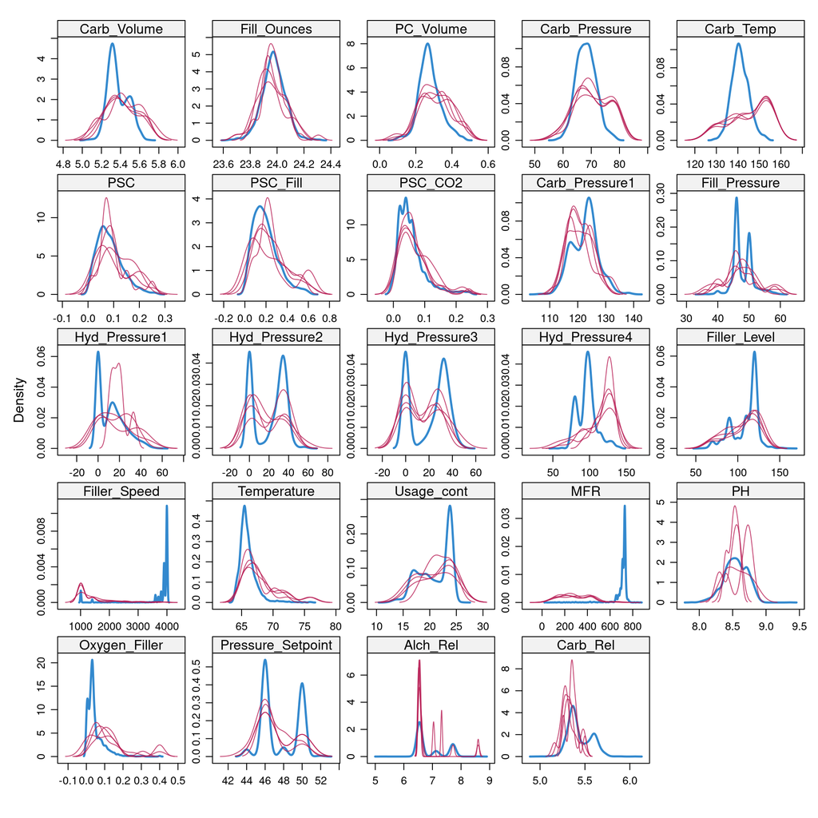

### Remove Predictors With Low Frequencies

We can filter out near-zero variance predictors by using the `nearZeroVar` function from the `caret` package.

```r
beverage_train <- beverage_train[, -nearZeroVar(beverage_train)]
beverage_test <- beverage_test[, names(beverage_train)]
```

### Removing Highly Correlated Predictors

We will use the methodology outlined in page 163 of the Applied Predictive Modeling textbook by Kuhn and Johnson in order to ensure that the absolute pairwise correlation between the predictors is less than 0.75. For the `beverage_test` set that will be used to generate the final predictions, only the predictors that were selected from the `beverage_train` dataset after filtering out the highly correlated predictors will be used.

Before the removal of the highly correlated predictors is performed. We must be cognizant of the fact that PLS models “allows you to reduce the dimensionality of correlated variables and model the underlying, shared, information of those variables (in both dependent and independent variables).” ([source](http://webcache.googleusercontent.com/search?q=cache:o5QYlxuDAvYJ:https://towardsdatascience.com/partial-least-squares-f4e6714452a&client=ubuntu&hl=en&gl=us&strip=1&vwsrc=0)). Therefore, we will be using all of the remaining variables for the PLS model generated in the “Partial Least Squares” section.

```r
tooHigh <- findCorrelation(cor(beverage_train %>%
  select(-c(Brand_Code, PH))), cutoff = 0.75)

beverage_train_high_corr <- beverage_train
beverage_test_high_corr <- beverage_test

beverage_train <- beverage_train[, -tooHigh]
beverage_test <- beverage_test[, -tooHigh]
```

### Yeo-Johnson Transformations, Centering, Scaling

Page 54 in the Applied Predictive Modeling textbook explains that:

“To administer a series of transformations to multiple data sets, the `caret` class preProcess has the ability to transform, center, scale, or impute values, as well as apply the spatial sign transformation and feature extraction. The function calculates the required quantities for the transformation. After calling the `preProcess` function, the `predict` method applies the results to a set of data.”

In the `train` function in the `caret` package, there is a `preProcess` parameter. The `train` function is what will be used to create the models in the following sections. This `preProcess` parameter will be set to a vector containing any combination of these 3 strings: `YeoJohnson`, `center`, `scale`. These three strings perform the appropriate YeoJohnson transformations in addition to centering and scaling the predictors. We originally were going to perform Box-Cox transformations, but the summary of the dataset revealed that some of the predictors contained negative values (`Mnf Flow`, `Hyd Pressure3`, etc.). Centering and scaling is generally performed to improve the numerical stability of some calculations. As explained on page 31 of the Applied Predictive Modeling textbook, PLS models benefit from predictors being in a common scale.

### Data Splitting

We’re going to use the Pareto Principle to split the data. Wikipedia explains that:

“The Pareto principle states that for many outcomes, roughly 80% of consequences come from 20% of causes (the”vital few”).”

Therefore, we will be employing an 80/20 split to the `beverage_train` dataset.

```r
set.seed(1)
sample <- sample.split(beverage_train$PH, SplitRatio = 0.8)

train_X  <- subset(beverage_train %>% select(-PH), sample == TRUE)
test_X   <- subset(beverage_train %>% select(-PH), sample == FALSE)
train_y <- subset(beverage_train$PH, sample == TRUE)
test_y <- subset(beverage_train$PH, sample == FALSE)

sample_high_corr <- sample.split(beverage_train$PH, SplitRatio = 0.8)

train_X_high_corr <- subset(beverage_train_high_corr %>% select(-PH), sample == TRUE)
test_X_high_corr <- subset(beverage_train_high_corr %>% select(-PH), sample == FALSE)
train_y_high_corr <- subset(beverage_train_high_corr$PH, sample == TRUE)
test_y_high_corr <- subset(beverage_train_high_corr$PH, sample == FALSE)
```

## General Modeling

For some of the models, we will be using the `trControl` parameter in the `caret::train` function. Reason why is explained in page 130 of the Applied Predictive Modeling textbook:

“The `train` function generates a resampling estimate of performance. Because the training set size is not small, 10-fold cross-validation should produce reasonable estimates of model performance. The function `trainControl` speciﬁes the type of resampling.”

We will be using the testing set to compute the testing set RMSE, Rsquared, and MAE. We will use these metrics to select the best model.

Some of the models will not allow categorical variables to be used, which means the `Brand Code` variable cannot be used in these model types. Converting a categorical variable to a numerical one can be done, but since the `Brand Code` variable takes on more than two different categories, the conversion would not be advantageous. As explained by Ashkon Farhangi:

“In the vast majority of cases using dummy variables is more statistically sound than using a single numerical variable. A single numerical variable does not accurately encode the information represented by a categorical variable, because of the relationships between numerical values it implicitly implies. On the number line, 1 is closer to 2 than it is to 3. However, by definition no pair of values assumed by categorical variables is more similar than any other. Encoding three such values as 1, 2 and 3 will result in the model inferring incorrect relationships between those numbers. The fact that real valued numbers fall on a number line that implies a greater degree of similarity between values that fall closer to one another along it; this notion is incompatible with categorical variables. Using dummy variables avoids this pitfall.”

Models where the `Brand Code` predictor was not used include:

- Penalized Regression
- Support Vector Machines
- K-Nearest Neighbors

```r
ctrl <- trainControl(method = "cv", number = 10)
```

### Linear Regression Modeling

#### Ordinary Linear Regression

```r
olr_model <- caret::train(train_X, train_y,
                          method = "lm",
                          trControl = ctrl,
                          preProcess = c("YeoJohnson", "center", "scale"))

olr_pred <- predict(olr_model, newdata = data.frame(test_X))
postResample(pred = olr_pred, obs = test_y)
```

```
##      RMSE  Rsquared       MAE
## 0.1349479 0.3687633 0.1053912
```

#### Partial Least Squares

```r
set.seed(100)

pls_model <- train(train_X_high_corr,
                   train_y_high_corr,
                   method = "pls",
                   tuneLength = 20,
                   trControl = ctrl,
                   preProc = c("center", "scale"))

pls_pred <- predict(pls_model, newdata = test_X_high_corr)
postResample(pred = pls_pred, obs = test_y_high_corr)
```

```
##      RMSE  Rsquared       MAE
## 0.1347655 0.3711381 0.1044757
```

#### Penalized Regression Model

```r
## Define the candidate set of values
ridgeGrid <- data.frame(.lambda = seq(0, .1, length = 15))

set.seed(100)

ridgeReg_model <- train(train_X[,-1] %>% as.matrix(),
                        train_y %>% as.vector(),
                        method = "ridge",
                        tuneGrid = ridgeGrid,
                        trControl = ctrl,
                        preProc = c("center", "scale"))

ridgeReg_pred <- predict(ridgeReg_model, newdata = test_X[,-1] %>% as.matrix())
postResample(pred = ridgeReg_pred, obs = test_y %>% as.vector())
```

```
##      RMSE  Rsquared       MAE
## 0.1425452 0.2953001 0.1106143
```

### Non-Linear Regression Modeling

```r
# nnetGrid <- expand.grid(.decay = c(0, 0.01, .1),
#                         .size = c(1:10),
#                         .bag = FALSE)
#
# set.seed(100)
#
# nnet_model <- train(train_X, train_y,
#                   method = "avNNet",
#                   tuneGrid = nnetGrid,
#                   trControl = ctrl,
#                   preProc = c("center", "scale"),
#                   linout = TRUE,
#                   trace = FALSE,
#                   MaxNWts = 84851,
#                   maxit = 500)
#
# nnet_pred <- predict(nnet_model, newdata = data.frame(test_X))
# postResample(pred = nnet_pred, obs = test_y)
```

#### Multivariate Adaptive Regression Splines

```r
marsGrid <- expand.grid(.degree = 1:2, .nprune = 2:38)

set.seed(100)

mars_model <- train(train_X,
                    train_y,
                    method = "earth",
                    tuneGrid = marsGrid,
                    preProcess = c("YeoJohnson"),
                    trControl = trainControl(method = "cv"))
mars_pred <- predict(mars_model, newdata = test_X)
postResample(pred = mars_pred, obs = test_y)
```

```
##       RMSE   Rsquared        MAE
## 0.12362021 0.47383641 0.09366559
```

#### Support Vector Machines

```r
svmR_model <- train(train_X[,-1] %>% as.matrix(),
                    train_y %>% as_vector(),
                    method = "svmRadial",
                    preProc = c("YeoJohnson", "center", "scale"),
                    tuneLength = 14,
                    trControl = trainControl(method = "cv"))

svmR_pred <- predict(svmR_model, newdata = test_X[,-1] %>% as.matrix())
postResample(pred = svmR_pred, obs = test_y %>% as_vector())
```

```
##       RMSE   Rsquared        MAE
## 0.13009674 0.41861363 0.09385914
```

#### K-Nearest Neighbors

```r
set.seed(100)

knn_model <- train(train_X[,-1] %>% as.matrix(),
                   train_y %>% as_vector(),
                   method = "knn",
                   preProc = c("center", "scale"),
                   tuneGrid = data.frame(.k = 1:20),
                   trControl = trainControl(method = "cv"))

knn_pred <- predict(knn_model, newdata = test_X[,-1] %>% as.matrix())
postResample(pred = knn_pred, obs = test_y %>% as_vector())
```

```
##       RMSE   Rsquared        MAE
## 0.13242439 0.39427027 0.09633514
```

## Regression Trees and Rule-Based Models

According to this Medium article:

“Decision trees and ensemble methods do not require feature scaling to be performed as they are not sensitive to the the variance in the data.”

#### Single Trees Model

```r
single_trees_model <- train(train_X,
                            train_y,
                            method = "rpart2",
                            tuneLength = 10,
                            preProcess = c("YeoJohnson"),
                            trControl = trainControl(method = "cv"))

single_trees_pred <- predict(single_trees_model, newdata = test_X)
postResample(pred = single_trees_pred, obs = test_y)
```

```
##      RMSE  Rsquared       MAE
## 0.1270852 0.4419870 0.1007020
```

#### Model Tree

```r
set.seed(100)

tree_model <- train(
                train_X,
                train_y,
                method = "M5",
                trControl = trainControl(method = "cv"),
                preProcess = c("YeoJohnson"),
                control = Weka_control(M = 10))

tree_pred <- predict(tree_model, newdata = test_X)
postResample(pred = tree_pred, obs = test_y)
```

```
##      RMSE  Rsquared       MAE
## 0.1285445 0.4280634 0.0984317
```

#### Bagged Tree Model

```r
bagged_tree_model <- ipredbagg(train_y,
                               train_X,
                               preProcess = c("YeoJohnson"))

bagged_tree_pred <- predict(bagged_tree_model, newdata = test_X)
postResample(pred = bagged_tree_pred, obs = test_y)
```

```
##       RMSE   Rsquared        MAE
## 0.11883266 0.51253133 0.09303323
```

#### Random Forest Model

```r
rf_model <- randomForest(train_X, train_y,
                         preProcess = c("YeoJohnson", "center", "scale"),
                        importance = TRUE,
                        ntrees = 1000)

rf_pred <- predict(rf_model, newdata = test_X)
postResample(pred = rf_pred, obs = test_y)
```

```
##       RMSE   Rsquared        MAE
## 0.09741691 0.68194538 0.07087061
```

#### Boosted Tree Model

```r
gbmGrid <- expand.grid(.interaction.depth = seq(1, 7, by = 2),
                       .n.trees = seq(100, 1000, by = 50),
                       .shrinkage = c(0.01, 0.1),
                       .n.minobsinnode = 10)

set.seed(100)

gbmTune <- train(train_X,
                 train_y,
                 method = "gbm",
                 preProcess = c("YeoJohnson"),
                 tuneGrid = gbmGrid,
                 verbose = FALSE)

gbm_pred <- predict(gbmTune, newdata = test_X)
postResample(pred = gbm_pred, obs = test_y)
```

```
##       RMSE   Rsquared        MAE
## 0.10398233 0.62794984 0.07728084
```

#### Cubist

```r
cubistTuned <- train(
  train_X,
  train_y,
  preProcess = c("YeoJohnson"),
  method = "cubist")

cubist_pred <- predict(cubistTuned, newdata = test_X)
postResample(pred = cubist_pred, obs = test_y)
```

```
##       RMSE   Rsquared        MAE
## 0.10089544 0.64860365 0.07316991
```

## Modeling Selection

In this section, the model that will be selected to generate the final test predictions will be selected. The selection criteria comes down to three metrics. These three metrics were generated using the `postResample` function:

- [MAE](https://www.reddit.com/r/explainlikeimfive/comments/8axf23/eli5_what_is_the_difference_between_mean_absolute/)
  - Measures average distance of each measurement from the total average value. Small errors drown out rare, but large errors.
- [RMSE](https://help.sap.com/docs/SAP_PREDICTIVE_ANALYTICS/41d1a6d4e7574e32b815f1cc87c00f42/5e5198fd4afe4ae5b48fefe0d3161810.html)
  - This is the MAE, but the error is squared, then the entire square root of the equation is taken. This is to reduce the effect of small errors will increasing the effect of large errors.
- [Rsquared](https://www.investopedia.com/terms/r/r-squared.asp)
  - Represents how much of the variation of a dependent variable is explained by an independent variable in a regression model.